# Financial Contributions to Presidential Campaigns in Washington,by Fareeda Saleh

```
## [1] "C:/Users/Fareeda/Desktop/Project4"
```

```
##  [1] "cmte_id"           "cand_id"           "cand_nm"
##  [4] "contbr_nm"         "contbr_city"       "contbr_st"
##  [7] "contbr_zip"        "contbr_employer"   "contbr_occupation"
## [10] "contb_receipt_amt" "contb_receipt_dt"  "receipt_desc"
## [13] "memo_cd"           "memo_text"         "form_tp"
## [16] "file_num"          "tran_id"           "election_tp"
## [19] "x"
```

```
##  [1] "cand_id"           "cand_nm"           "contbr_nm"
##  [4] "contbr_city"       "contbr_st"         "contbr_zip"
##  [7] "contbr_employer"   "contbr_occupation" "contb_receipt_amt"
## [10] "contb_receipt_dt"  "receipt_desc"      "memo_cd"
## [13] "memo_text"         "form_tp"           "file_num"
## [16] "tran_id"           "election_tp"       "x"
```

# Introduction

In this report we will explor the Financial Contributions to Presidential Campaigns.We choose the dataset of Washington state from Federal Election Commission http://fec.gov/disclosurep/pnational.do for the year 2016.We have 18 varibles and 292317 observations.Through this project we will try to answer some question:

What is the party has most support?

Who the candidates has the most support?

Does the gender play critical role in donation?

What is the occupation of the most doners?

Now lets view som summary information about the data:

```
##    cmte_id               cand_id                            cand_nm
##  Length:292317      P00003392:126190   Clinton, Hillary Rodham  :126190
##  Class :character   P60007168:121555   Sanders, Bernard         :121555
##  Mode  :character   P80001571: 16222   Trump, Donald J.         : 16222
##                     P60006111: 13357   Cruz, Rafael Edward 'Ted': 13357
##                     P60005915:  8085   Carson, Benjamin S.      :  8085
##                     P60006723:  2192   Rubio, Marco             :  2192
##                     (Other)  :  4716   (Other)                  :  4716
##               contbr_nm          contbr_city     contbr_st
##  BUNSON, JAMIE     :   282   SEATTLE   : 82399   WA:292317
##  TREIBEL, RANDY    :   280   VANCOUVER :  9555
##  BUCKLEY, MARK     :   262   OLYMPIA   :  8965
##  WATSON, DONNA     :   256   BELLINGHAM:  8105
##  BENACK, MARY ANN  :   214   TACOMA    :  8075
##  SOMERVILLE, DALENE:   191   BELLEVUE  :  7942
##  (Other)           :290832   (Other)   :167276
##      contbr_zip          contbr_employer               contbr_occupation
##  98053    :   351   N/A          : 40677   RETIRED              : 58036
##  981556413:   282   NONE         : 28069   NOT EMPLOYED         : 38766
##  98033    :   271   RETIRED      : 26858   INFORMATION REQUESTED:  6361
##  98004    :   266   SELF-EMPLOYED: 15757   SOFTWARE ENGINEER    :  5494
##  981882718:   266   NOT EMPLOYED : 15214   TEACHER              :  5035
##  991633631:   246   (Other)      :165561   (Other)              :178587
##  (Other)  :290635   NA's         :   181   NA's                 :    38
##  contb_receipt_amt   contb_receipt_dt
##  Min.   :-8432.99   31-MAR-16:  3443
##  1st Qu.:   15.00   29-FEB-16:  3323
##  Median :   27.00   31-MAY-16:  2576
##  Mean   :   82.95   30-MAR-16:  2549
##  3rd Qu.:   60.00   30-APR-16:  2540
##  Max.   :10800.00   09-MAR-16:  2312
##                     (Other)  :275574
##                                                            receipt_desc
##                                                                  :289441
##  Refund                                                          :  1851
##  REDESIGNATION FROM PRIMARY                                      :   190
##  REDESIGNATION TO GENERAL                                        :   189
##  REDESIGNATION TO CRUZ FOR SENATE                                :   112
##  * EARMARKED CONTRIBUTION: SEE BELOW REATTRIBUTION/REFUND PENDING:    99
##  (Other)                                                         :   435
##  memo_cd                                  memo_text       form_tp
##   :255653                                      :150366   SA17A:254860
##  X: 36664   * EARMARKED CONTRIBUTION: SEE BELOW:117320   SA18 : 35606
##             * HILLARY VICTORY FUND             : 22912   SB28A:  1851
##             *BEST EFFORTS UPDATE               :   236
##             EARMARKED FROM MAKE DC LISTEN      :   202
##             REDESIGNATION FROM PRIMARY         :   190
##             (Other)                            :  1091
##     file_num            tran_id       election_tp
##  Min.   :1003942   C1014570 :     2        :   364
##  1st Qu.:1077665   C10180161:     2   G2016: 89381
##  Median :1093618   C10182232:     2   O2016:   109
##  Mean   :1099341   C10183207:     2   P2016:202462
##  3rd Qu.:1133832   C1022004 :     2   P2020:     1
##  Max.   :1146285   C10225858:     2
##                    (Other)  :292305
```

We can see some issues in contb_receipt_amt column, First, the min value is negative and this is not acceptable.It may come from data entry mistake so we should delete the negatives values.Another thing is the max value equal to 10800 which is according to Contribution Limits for 2015-2016 http://www.fec.gov/info/contriblimitschart1516.pdf the limits on contributions should not exceed 2700$ for the individual, so we will delete the values upper than 2700.

Now we will add some variables(gender and party) to help us in analyze the data

Now let’s view the data set after an update it by deleting the negative values(2905) and values upper than 2700(1504) from contb_reiecpt_amt , add new variables:

-gender: The gender of donor women or men.

-party: The party of the candidate(Democrat, Republican or others )

```
## [1] 279876     22
```

So we have 22 variables and 279876 observation.Each single observation is represent a single donor.

## General View

We will investigate the contribution distribution across the parties, candidates, genders and occupations.first we will drawing histogram for contribuation.

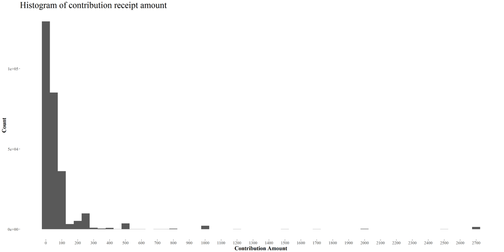

The histogram was unuseful to display the details of the contribution receipt amount.There are many outliers high and low values, So we will transform it to log10.

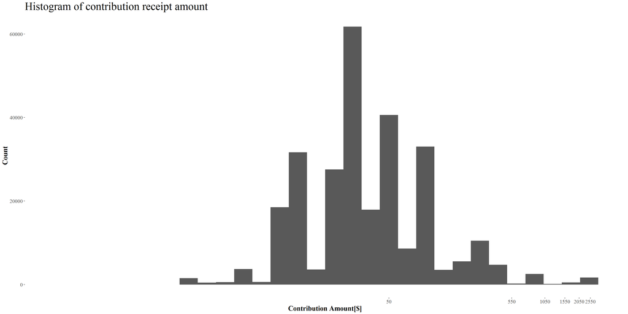

```
##    Min. 1st Qu.  Median    Mean 3rd Qu.    Max.
##    0.09   15.00   27.00   85.49   64.03 2700.00
```

We can see that few donors made high donation when most people are donate with 27$ also few people made donation less than 5 dollars and the mean is 85.49 per individual.

```
## [1] 279876
```

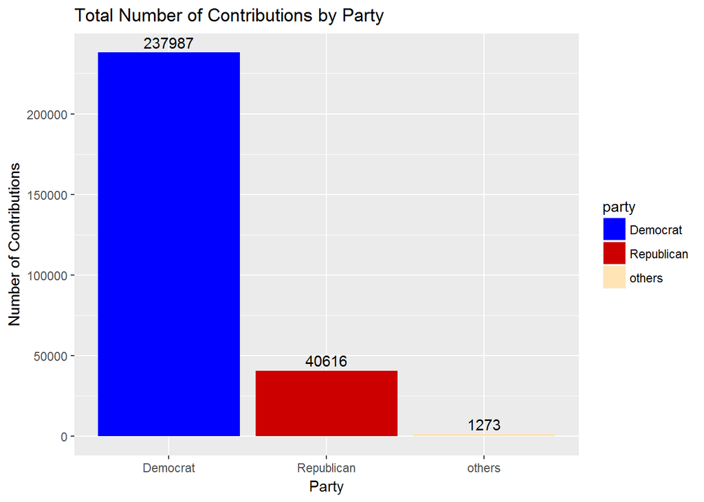

ok,lets see How many doners countribute for each candidites?

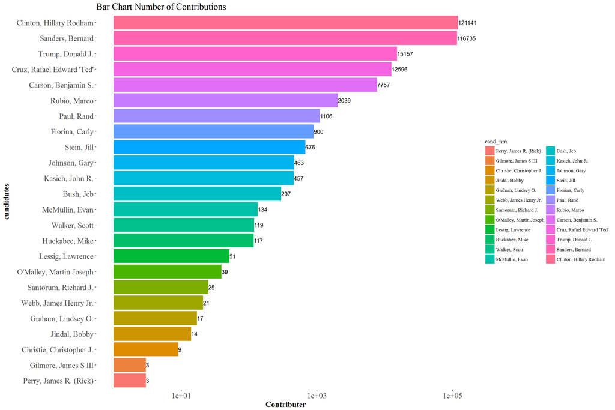

There is 16 candidates from the Republican party , 5 from Democrat and 3 from other paties,However Hillary and Sanders which are both from Democatic party has the most doners then fallow by Trump from the Rbuplican party and the less support by doners are Glimore,James and Perry James they just has 3 doners.

So,how many male and female contribute in donation?

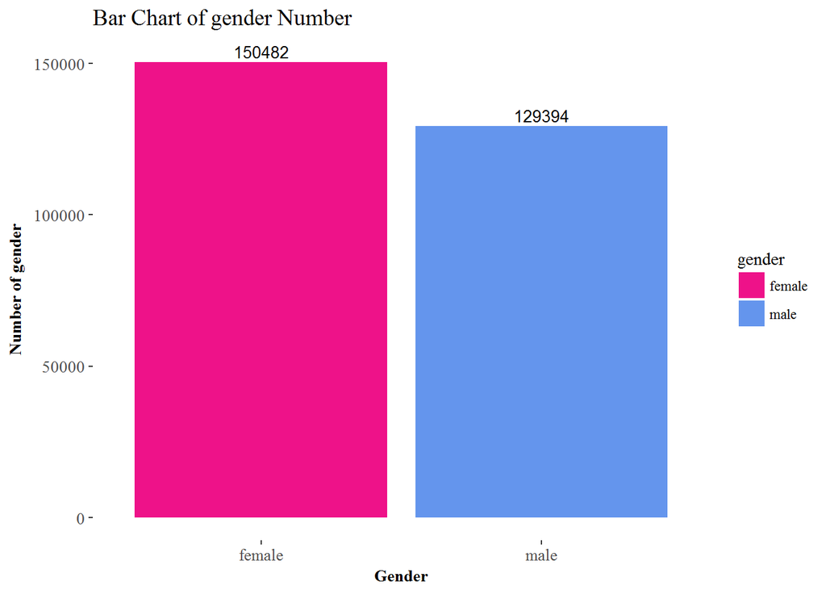

we can see female is contributed more than male there is 150482 women donate while the number of males who donate is 129394 it’s [54% to 46%]

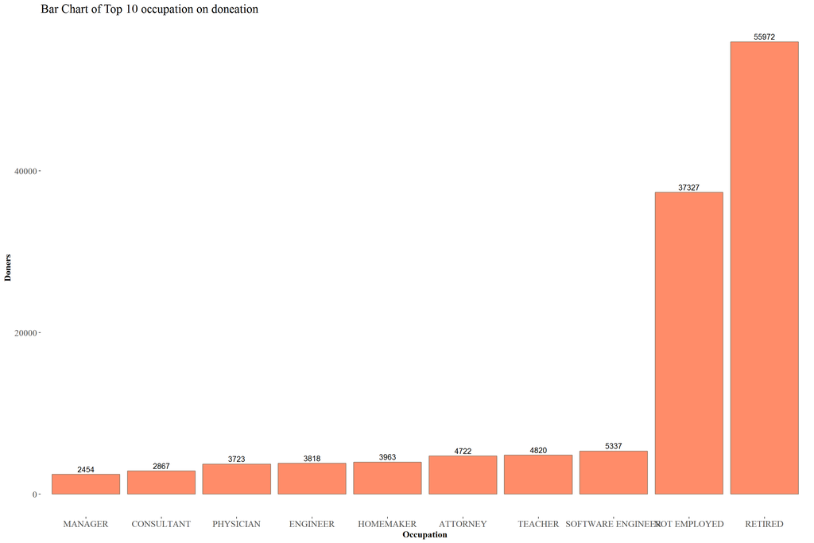

The highest number of donors are Retired wich has 44% from total numbers of donors the next stage was people who don’t employed by 31% and this while the last is managers by 1% and this is really surprise me according to the income average it should be the physician and managers first place of the list.

## Parties,Candidete and Donations

In this section of our analyses, We will explore how parties effect on the donation and how much each candidate received from the donation operation.first the total of contribution amount are 23926435$ and we have 5 candidates from democrat party and 16 candidates from republican party and 3 from another party so we assume that the republican will earn more money than democrat party and others party according to the numbers of his candidates,Now let’s investigate the contribution amount according to parties by drawing a box plot.

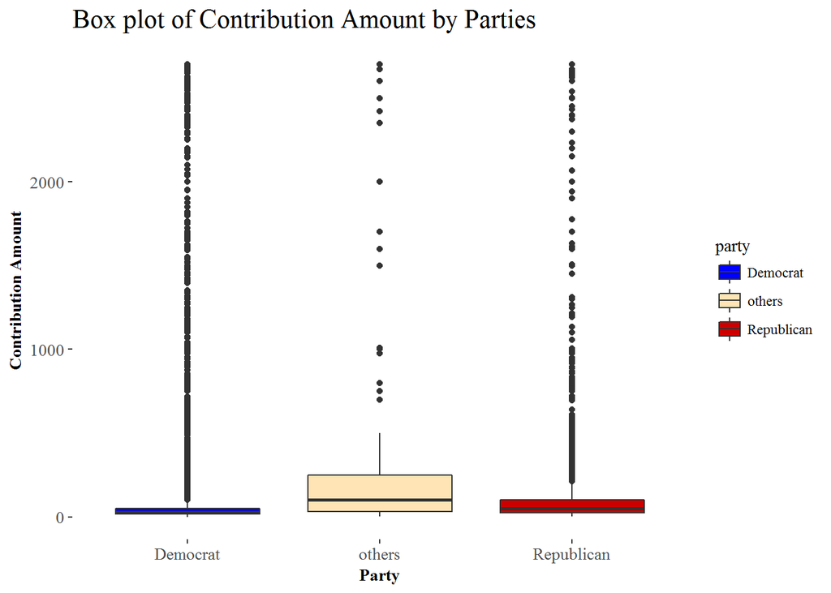

The box plot have more outliers so we will apply the log10 transformation

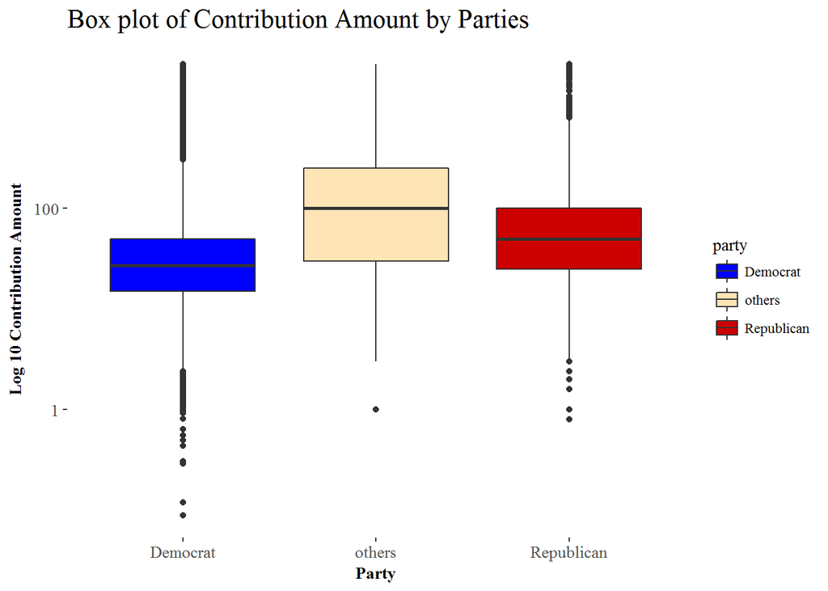

Now lets draw bar chart to see how much each party earn and what is the average of donation for both parties:

```
## # A tibble: 3 × 4
##        party      Total cnd_l       Avg
##        <chr>      <dbl> <int>     <dbl>
## 1   Democrat 18026848.3     5 3605369.7
## 2     others   321021.8     3  107007.3
## 3 Republican  5578565.3    16  348660.3
```

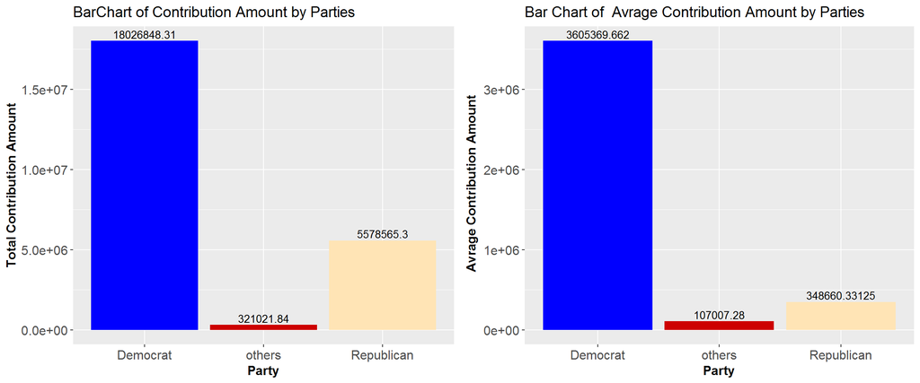

We can see the number of candidates did not affect the donation amount for parties, the democrat party received in total about 18026000 thousand dollars it’s 75% of total donation , each democrat candidates received in average about 3605000 thousand dollars, so we can see the high difference between democrat and republican it’s 52% of total donation and the others parties has the less support by 1%. This will lead us to focus on the candidates variables, we try now to answer the question how much each candidates received from the donors?

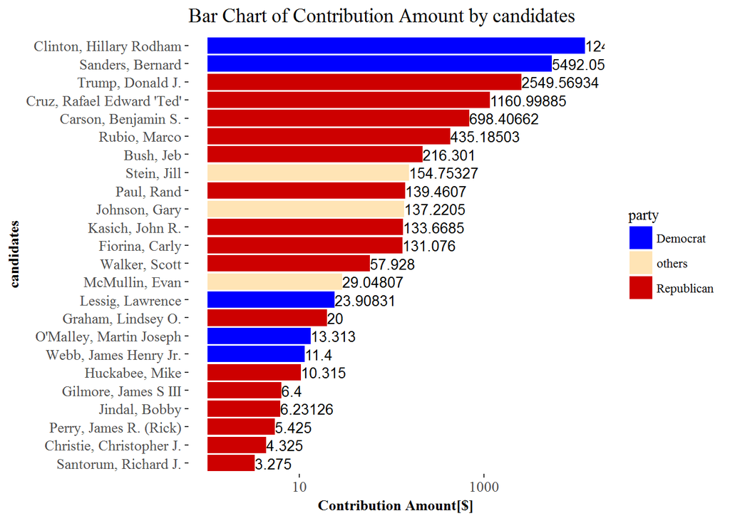

The top 2 in the amount donation is Hillary and Sanders which are both from democrat party, Sanders received donation less than 50% of Hillary amount donation, The things that I interested in is the majority of democrat party donation goes to Hillary and Sanders.Now lets take the top 3 of the candidates and explore how many donors made a donation for them?

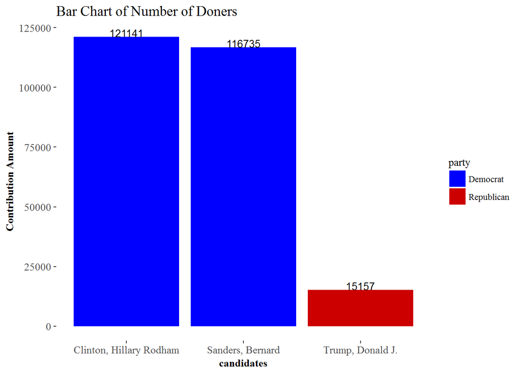

it’s very clear that Trump has the lowest number of donors the difference btween hem and sanders,Hillary are very huge,However the important things that I notice in this diagram that sanders are very close to Hillary,in other hand Hillary are received more than 50%of donations than sanders so this leading us to explore the distribution of amount of each of them:

```
## Source: local data frame [4,341 x 4]
## Groups: cand_nm [3]
##
##                    cand_nm contb_receipt_amt Total_d donor_nm
##                     <fctr>             <dbl>   <dbl>    <int>
## 1  Clinton, Hillary Rodham              0.09    0.09        1
## 2  Clinton, Hillary Rodham              0.12    0.12        1
## 3  Clinton, Hillary Rodham              0.29    0.29        1
## 4  Clinton, Hillary Rodham              0.31    0.31        1
## 5  Clinton, Hillary Rodham              0.44    0.44        1
## 6  Clinton, Hillary Rodham              0.82    0.82        1
## 7  Clinton, Hillary Rodham              0.92    0.92        1
## 8         Sanders, Bernard              1.02    1.02        1
## 9         Sanders, Bernard              1.05    1.05        1
## 10        Sanders, Bernard              1.08    1.08        1
## # ... with 4,331 more rows
```

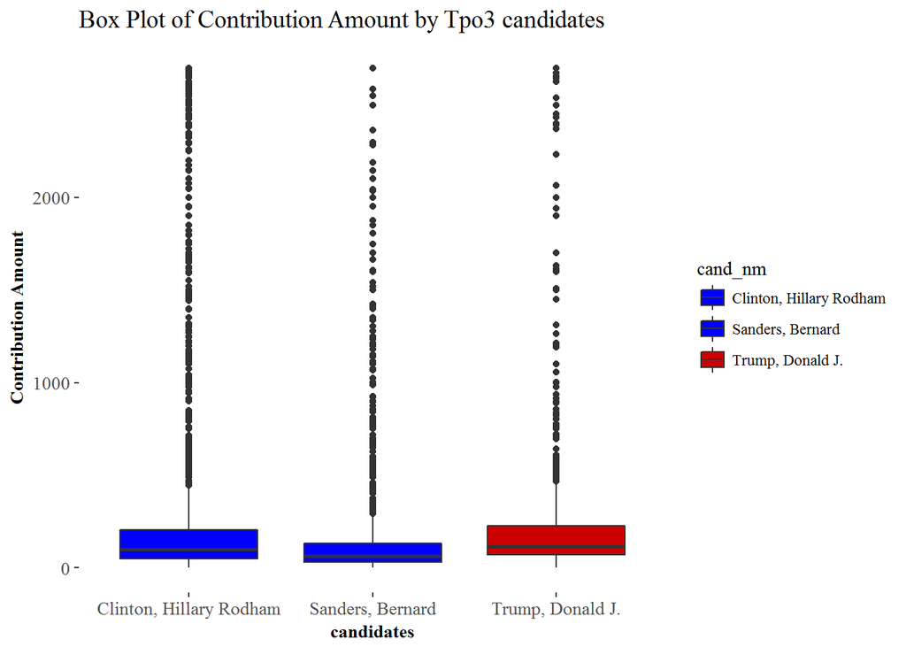

we can see alot of donors that made a huge amount of donations for Hillary but I think we should transforming the box plot to log10 to see more details.

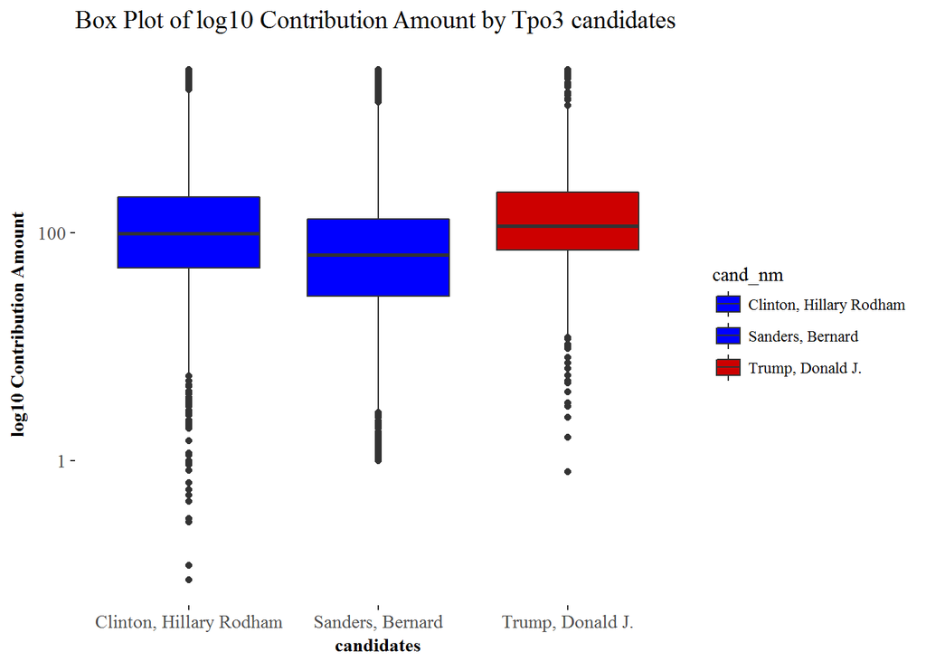

## Gender and Donation

In this section, we will focus on the variable of gender and we will try to answer the how gender play role in the donation,Now let’s see the contribution according to gender by drawing an histogram

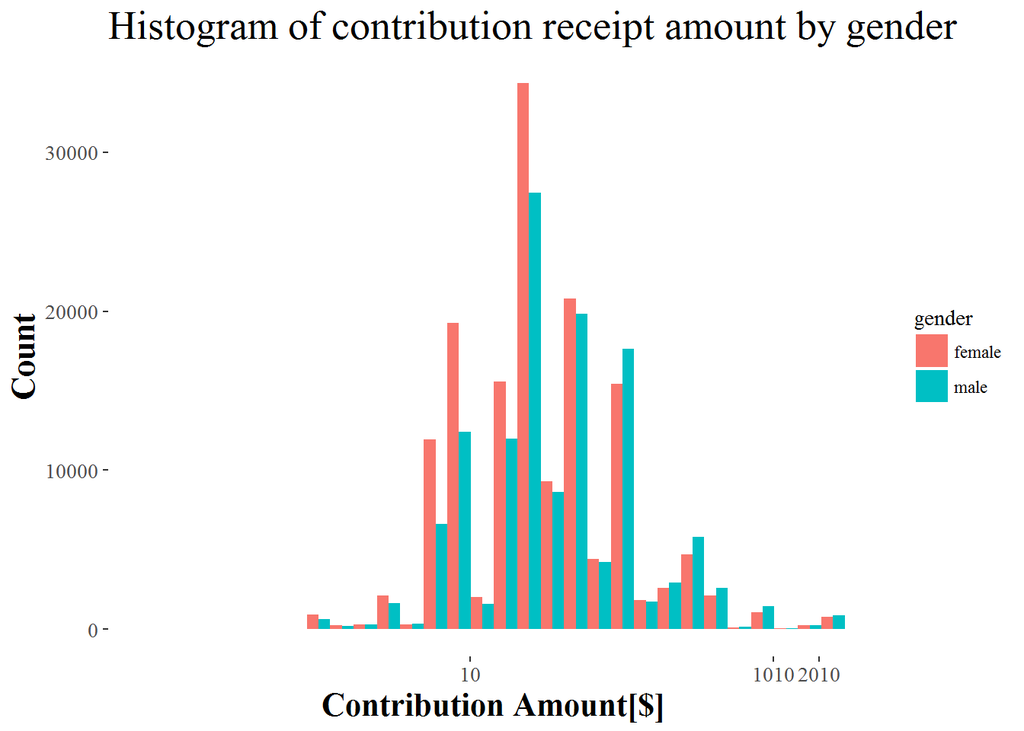

we can see female has high scales in the first half of histogram then they start to decrease the male has higher distribution in the end of histogram than female and that means males contribute with high donation than females.Ok,lets How Much amount of donation they made.

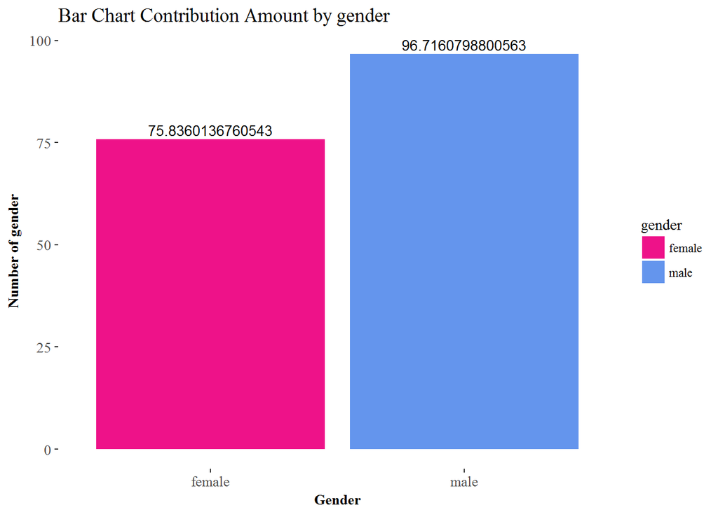

when we focus on the amount of contribution the male has higher contribution than female the average of what male donate is 96.71608 dollars while the average of what female donate is 75.83601 dollars, This could be occure because the average of female salary is less than male or because some women are house wife.Now let see which parties are more supported by males or females?

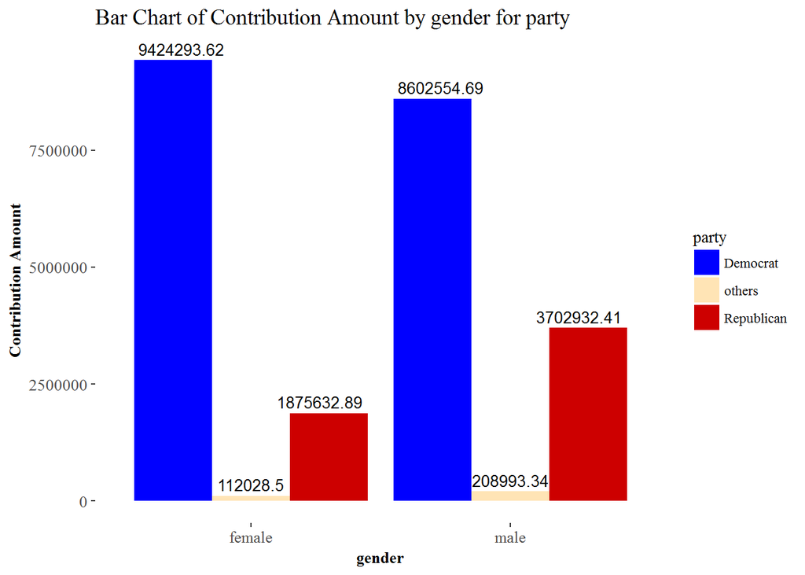

The females support the democrat party more than males in other hands the republican are supported by men than women Also the others parties are supported by males who donate more than 50% of what women donate for these parties.

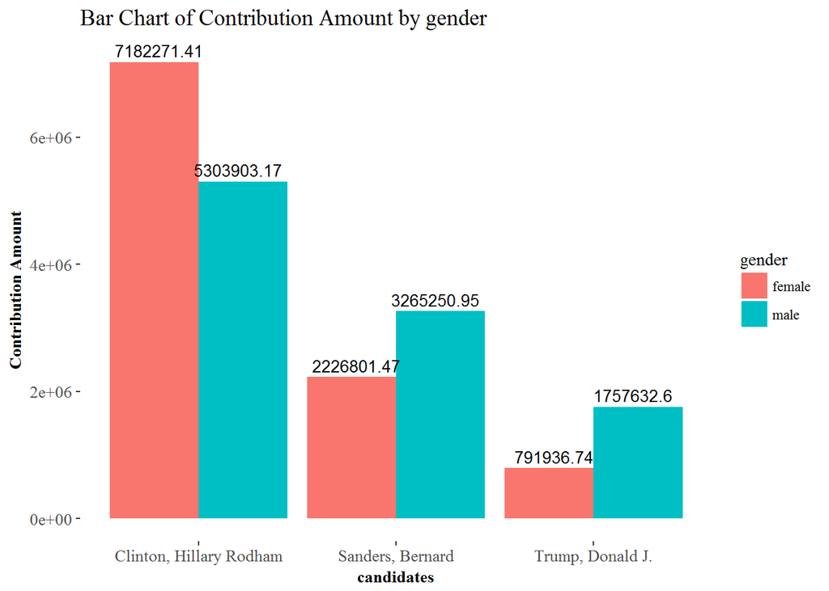

Hillary has most support from women while Sanders and Trump has the less support by women and high support by mean,for my opinion we can not say women tend to support woman candidate because Hillary has the highest support from either male or female.However if there were another women candidates and they have support by females in this setuation we can say that women mostly tend to support woman candidates.

# Occupation and Donations

Now will focus in in the variable occupation and see if there is a relation between the occupation and the amount of contribution?

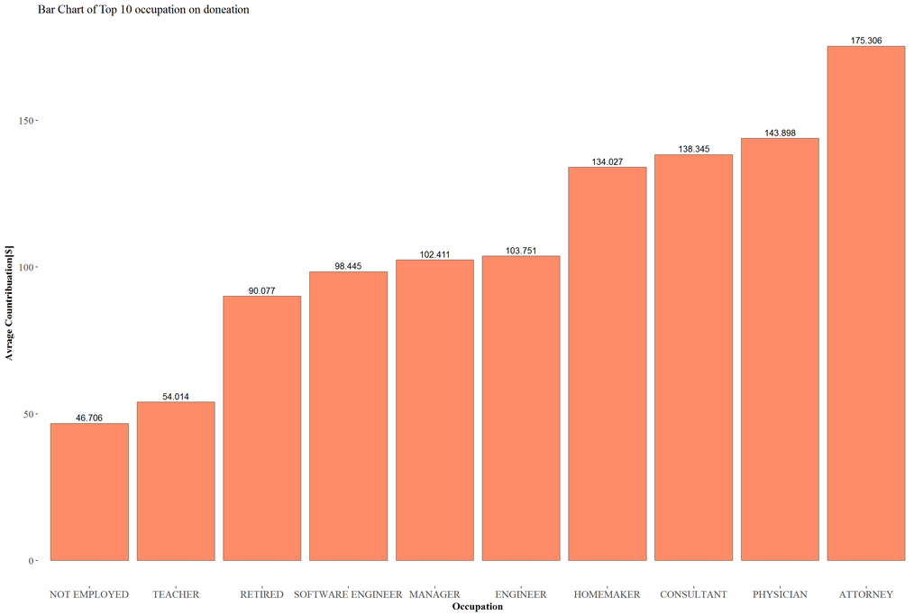

when we measured the average amount of donation we found that the attorney and physician are the highest contribution and donors who retired,teacher and not employed they are made small amount of donation.Now let see who these occupation support the parties and candidets.

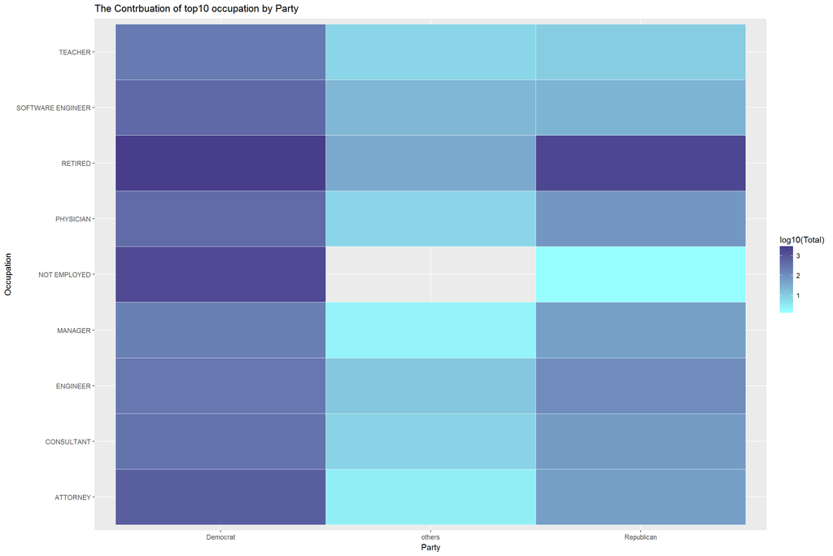

When we see the distribution of the contribution to these top 10 occupation most of these contribution goes to democrat party also we can see from the heat map the retired support the democratic party with above of 2990000 dollars which is the most contribution in the map on other hand they support republican with 2010000 dollars,The not employeed doners support the democrat party with 1740000 dollars and donate to republican with 1.546000 and this is big difference,Moreover they did not made any donation to others parties!!.

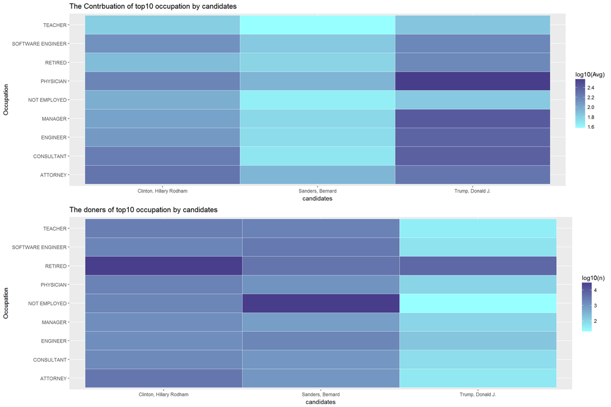

The most number of people not employed are donated to Sanders while the high number of retired donate to Hillary,also many donors donated to both Hillary and Sanders and Trump has the lowest number of donors especially from the not employee donors but he has high support from retired However when we focus on the Average amount of donation for all these occupation it’s clear that trump has the measure of the contribution and Sanders has the less amount of contribution.Physician made high donated to trump in average the donate with above of 300 dollars for individual.

# Final Plots and Summary

### A few candidates received Most donation

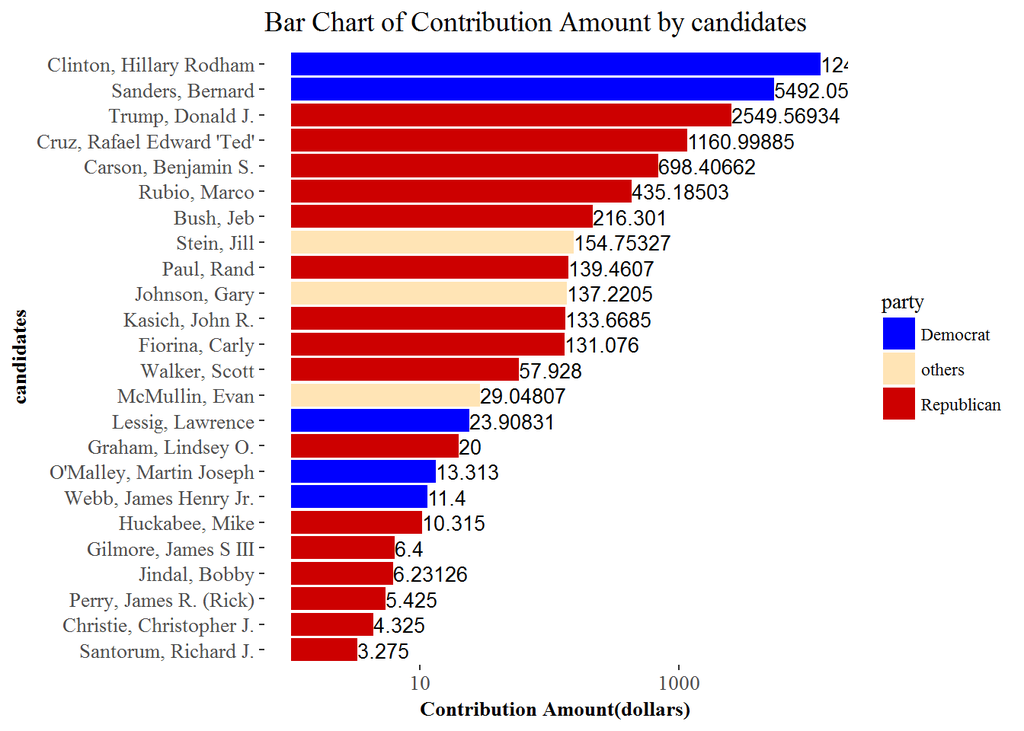

### Retired and not employed are tend to donate more than other occupation

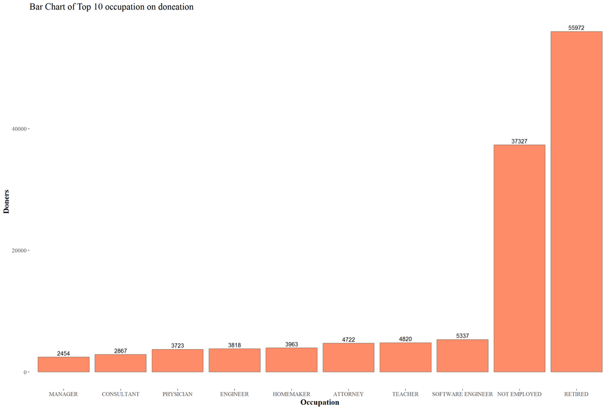

### Women tend to donate more than men

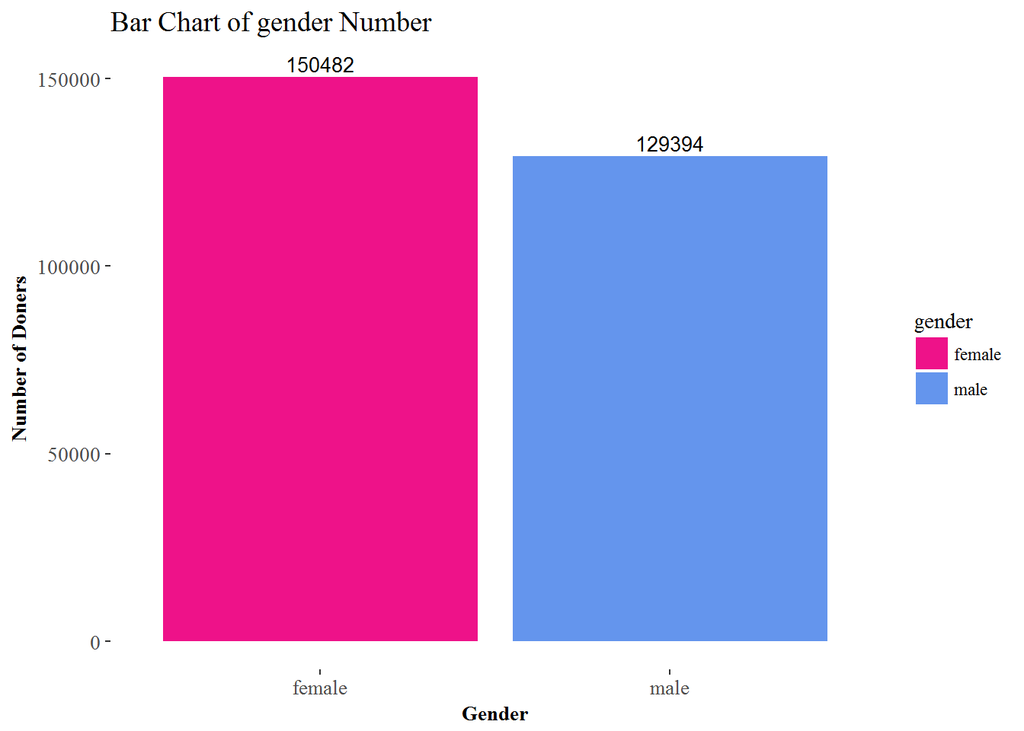

in the contribution amount of presidential campaigns in washington state we can see 54% of donors are women so the difference between women and men donors are 8% and most of women donate to Hillary,However when we focus in the amount countrbution we found the males has the highest percentage they contribute by 52% of the total donation amount.

# Reflection

In this project I analyzes the washington state which has 18 varibles and 292317 observations through this analysis I faced some issues:

when reading the data from CSV files there was an extra column and the others column was not arrange so I try to rearrange the columns. I had to add some variables to help me in analyzing the data set,In addition I struggled with the Age package because it is the first time I deal with it.

However there are some interesting finding I should to mention it :

-Washington state are highly support the democratic party, especially Hillary and Sanders.

-Most of donation go to few candidates.

-The Number of women who donate are more than men.

-The males tend to donate with large amount of money.

-Retired and the not employed are the most high number of donors

-The not employed people did not donate to other parties.

My future works is to explore another variables like the contributor city and also build a Predictive model to predict who is the person that will made the large donation?

# Resources:

R-bloggers: https://www.r-bloggers.com/making-faceted-heatmaps-with-ggplot2/ https://www.r-bloggers.com/aggregation-with-dplyr-summarise-and-summarise_each/

idre.ucla: http://stats.idre.ucla.edu/r/faq/frequently-asked-questions-about-rhow-can-i-subset-a-data-setthe-r-program-as-a-text-file-for-all-the-code-on-this-page-subsetting-is-a-very-important-component/

Files colors: http://www.stat.columbia.edu/~tzheng/files/Rcolor.pdf